# Assignment 4

202341436

10-01-2024

The report and code appendix will be uploaded at [here](https://github.com/KristenZ104/ASM4_MY472.git).

## Introduction

In the ever-evolving landscape of music, the question of an artist’s enduring legacy is a fascinating exploration into the dynamic interplay between time, taste, and cultural resonance. As we stand at the threshold of 2024, a critical inquiry beckons: How has the music of these renowned artists endured, and what features or characteristics might elucidate the enduring engagement of their work?

This research seeks to find the answer. It uses the current popularity of artists on Spotify as an indicator of popularity, analyze their fan base, recent release dates, number of tracks, song style, song ratings, and other factors to understand whether these artists will become popular in 2023.

## Data

Data is obtained from three sourses.

The first source of data is “the 100 greatest music artists” published by [Rolling Stone on their website](https://www.rollingstone.com/music/music-lists/100-greatest-artists-147446/) in December 2010. The website introduces the rankings, names, and descriptions of artists. Due to the dynamic loading of content about multiple artists on the website. The RSelenium package’s virtual WebDriver is used to extract webpage information efficiently.

The second source of data is [the Spotify Web API](https://developer.spotify.com/documentation/web-api). This is the Spotify website used to allow users to batchly obtain information about desired artists or tracks. Firstly, register an account and apply for API Key activation on Spotify. Then, use `httr` package’s POST method to obtain various information about the artists, including the number of followers of artists on Spotify, song genres, popularity, and so on.

The third source of data is [Musicbrainz API](https://musicbrainz.org/doc/MusicBrainz_API). The Musicbrainz website provides more information on artists including ratings, genres and tags, which can help us understand the popularity of more artists.

Combine data from different sources by artist name. Then, store the captured artist and track information in separate datasets, and save it in a local `Rdata` file. This approach allows for the analysis to proceed without the need for repeated data scraping. The relevant datasets, once compiled and saved locally, can be readily accessed by loading the respective Rdata files.

## Analysis

After capturing the data of Rolling Stones and the followers and popularity of artists on Spotify, take a preliminary look at the corresponding results:

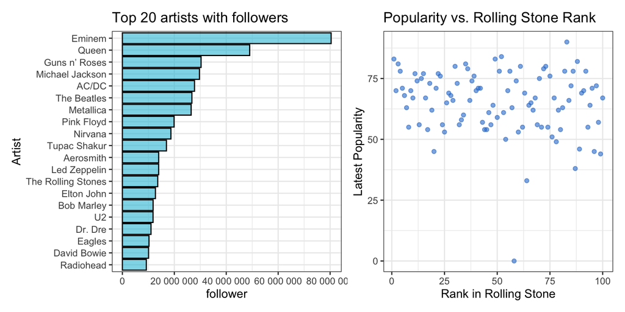

```r
library(tidyverse)
library(patchwork)

load("rollingstone.RData")

# Create a plot of the top 20 artists by followers on Spotify
p1 <- rollingstone_df_combined %>%
  mutate(rank_id = as.factor(rank_id)) %>% # Convert rank_id to a factor for better plotting
  arrange(-follower) %>% # Place the top 20 artists by followers in a descending manner
  head(20) %>%
  ggplot(aes(x=reorder(artist, follower), y=follower)) +
  geom_col(fill="#2cc1da", col="black", alpha=.6) + # Use colored bars to represent each artist
  labs(x="Artist", ylab="followers", title="Top 20 artists with followers") +
  scale_y_continuous(label=scales::label_number(accuracy = 1)) + # Format y-axis labels to round to the whole number
  coord_flip() + # Flip the plot to display horizontal bars
  theme_bw()

# Create a scatter plot showing the relationship between rank in Rolling Stone rank and latest popularity on Spotify
p2 <- ggplot(rollingstone_df_combined, aes(x=rank_id, y=popularity)) +
  geom_point(col="#2b7cd3", alpha=.6) + # Plot points for each artist
  labs(x="Rank in Rolling Stone", y="Latest Popularity",
       title="Popularity vs. Rolling Stone Rank") +
  theme_bw()

p1 + p2
```

Let’s take a look at the bottom 10 and top 10 artists respectively:

```r
# Explore the bottom 10 artists in terms of popularity
rollingstone_df_combined %>%
  arrange(popularity) %>% # Place the bottom 10 artists in an ascending pattern regarding popularity
  dplyr::select(rank_id, artist, popularity, genre) %>%
  head(10)
```

```
##    rank_id                      artist popularity               genre
## 1       58   Parliament and Funkadelic          0                NULL
## 2       64                Phil Spector         33  brill building pop
## 3       87                Gram Parsons         38 alternative country
## 4       99                Carl Perkins         44       rock-and-roll
## 5       20                  Bo Diddley         45      acoustic blues
## 6       96 Diana Ross and the Supremes         45  classic girl group
## 7       89               The Yardbirds         46          album rock
## 8       78                 The Stooges         49    alternative rock
## 9       54                Howlin’ Wolf         50      acoustic blues
## 10      76               The Shirelles         51  classic girl group
```

```r
# Explore the top 10 artists in terms of popularity
rollingstone_df_combined %>%
  arrange(-popularity) %>% # Place the top 10 artists in a descending pattern regarding popularity
  dplyr::select(rank_id, artist, popularity, genre) %>%
  head(10)
```

```
##    rank_id          artist popularity              genre
## 1       83          Eminem         90    detroit hip hop
## 2       52           Queen         84       classic rock
## 3        1     The Beatles         83   british invasion
## 4       49      Elton John         83          glam rock
## 5       88           Jay-Z         82 east coast hip hop
## 6        3   Elvis Presley         81      rock-and-roll
## 7       35 Michael Jackson         81                r&b
## 8       30         Nirvana         80             grunge
## 9       61       Metallica         80          hard rock
## 10      73       Radiohead         80   alternative rock
```

The band “Parliament and Funkadelic” seems to have undergone a name change, resulting in no valid information being retrieved from Spotify. Overall, among artists with lower popularity, they do not conform to a single or a few dominant musical styles, but rather span a broad spectrum of genres, reflecting a rich and varied musical landscape. Among the artists who have high popularity, it was found that hip hop and various rock categories are relatively high. However, Spotify’s detailed segmentation of genres presents a challenge in broadly classifying and analyzing these artists, as each represents a unique and specific niche within the larger musical genres.

Next, observe the impact of fan base, latest album release date, and average album track count on popularity:

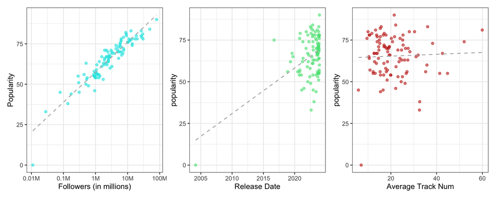

```r
# Visualization for the relationship between number of followers and popularity
p3 <- rollingstone_df_combined %>%
  ggplot(aes(x=follower, y=popularity)) +
  geom_point(col="#05e5e3", alpha=.6) +
  geom_smooth(method="lm", se=F, linewidth=.6, col="grey70", linetype="dashed") + # Add a linear regression line to visualize the trend
  labs(x="Followers (in millions)", y="Popularity") +
  scale_x_continuous(trans='log10', labels=function(x) paste0(x / 1e6, "M")) + # Apply a log transformation and label in millions
  theme_bw() +
  theme(plot.title = element_text(hjust = 0.5)) # Center the plot title

# Visualization for the relationship between album release date and popularity
p4 <- rollingstone_df_combined %>%
  ggplot(aes(x=release_date, y=popularity)) +
  geom_point(col="#58e285", alpha=.6) +
  geom_smooth(method="lm", se=F, linewidth=.6, col="grey70", linetype="dashed") + # Add a linear regression line to visualize the trend
  labs(x="Release Date") +
  theme_bw()

# Visualization for the relationship between average track number per album and popularity
p5 <- rollingstone_df_combined %>%
  ggplot(aes(x=track_num, y=popularity)) +
  geom_point(col="#c42b1c", alpha=.6) +
  geom_smooth(method="lm", se=F, linewidth=.6, col="grey70", linetype="dashed") + # Add a linear regression line to visualize the trend
  labs(x="Average Track Num") +
  theme_bw()

p3 + p4 + p5
```

From the picture, it can be seen that artists with more fans will have higher popularity. Also, the recent activity or new releases can contribute to an artist’s popularity. The average number of tracks per album does not seem to have a significant relationship with popularity.

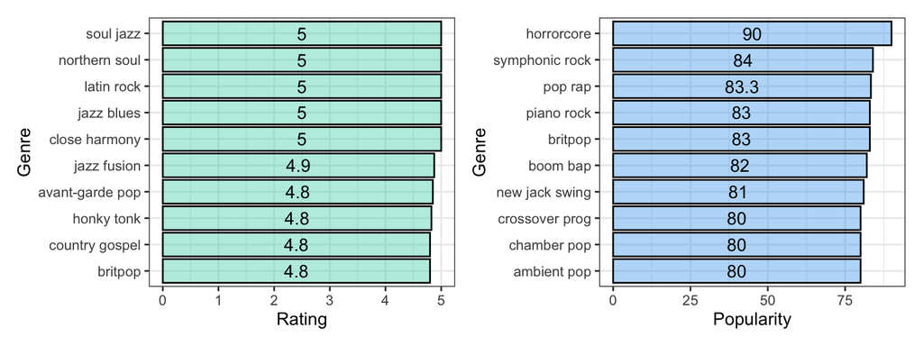

```r
load("musicbrainz_info.Rdata")

# Combine MusicBrainz data with Spotify popularity data
musicbrainz_info_combined <- musicbrainz_info %>%
  left_join(rollingstone_df_combined[, c("artist", "popularity")], by=c("artist_name"="artist"))

# Summarize the average rating and popularity by genre
genre_rating <- musicbrainz_info_combined %>%
  group_by(genre) %>%
  summarise(
    rating = mean(rating),
    popularity = mean(popularity)
  )

# Prepare a bar plot for the top 10 genres by average rating
p6 <- genre_rating %>%
  arrange(-rating) %>% # Arrange in descending order by average ratings in the data frame
  head(10) %>% # Select the top 10 genres
  ggplot(aes(x=reorder(genre, rating), y=rating)) + # Reorder genres based on their average ratings in the plot
  geom_col(fill="#40d2b1", col="black", alpha=.4) +
  geom_text(aes(label=round(rating, 1)), position = position_stack(vjust = 0.5)) + # Add text labels for ratings, and rounds them to one decimal place
  labs(x="Genre", y="Rating") +
  coord_flip() + # Flip the plot to display horizontal bars
  theme_bw()

# Prepare a bar plot for the top 10 genres by average popularity
p7 <- genre_rating %>%
  arrange(-popularity) %>% # Arrange in descending order by average popularity in the data frame
  head(10) %>% # Select the top 10 genres
  ggplot(aes(x=reorder(genre, popularity), y=popularity)) + # Reorder genres based on their average popularity in the plot
  geom_col(fill="#41a5ee", col="black", alpha=.4) +
  geom_text(aes(label=round(popularity, 1)), position = position_stack(vjust = 0.5)) + # Add text labels for popularity scores, and rounds them to one decimal place
  labs(x="Genre", y="Popularity") +
  coord_flip() + # Flip the plot to display horizontal bars
  theme_bw()

p6 + p7
```

From the results, it can be seen that various music styles have received positive reviews from the audience, with the most outstanding being soul jazz, northern soul, latin rock, jazz blues, and close harmony. In popularity, the most common styles are horrorcore, symphonic rock, pop rap, piano rock, and britpop. It shows that although jazz style will receive positive reviews, it hasn’t been able to continue to be popular. In popular styles, it is often the more cheerful and rhythmic music style. On the contrary, some more elegant music styles, although highly praised and selected as great artists, are difficult to sustain popularity in 2023.

## Appendix: All code in this assignment

```r
# this chunk contains code that sets global options for the entire .Rmd.
# we use include=FALSE to suppress it from the top of the document, but it will still appear in the appendix.

knitr::opts_chunk$set(echo = FALSE) # actually set the global chunk options.
# we set echo=FALSE to suppress code such that it by default does not appear throughout the document.
# note: this is different from .Rmd default
library(tidyverse)
library(patchwork)

load("rollingstone.RData")

# Create a plot of the top 20 artists by followers on Spotify
p1 <- rollingstone_df_combined %>%
  mutate(rank_id = as.factor(rank_id)) %>% # Convert rank_id to a factor for better plotting
  arrange(-follower) %>% # Place the top 20 artists by followers in a descending manner
  head(20) %>%
  ggplot(aes(x=reorder(artist, follower), y=follower)) +
  geom_col(fill="#2cc1da", col="black", alpha=.6) + # Use colored bars to represent each artist
  labs(x="Artist", ylab="followers", title="Top 20 artists with followers") +
  scale_y_continuous(label=scales::label_number(accuracy = 1)) + # Format y-axis labels to round to the whole number
  coord_flip() + # Flip the plot to display horizontal bars
  theme_bw()

# Create a scatter plot showing the relationship between rank in Rolling Stone rank and latest popularity on Spotify
p2 <- ggplot(rollingstone_df_combined, aes(x=rank_id, y=popularity)) +
  geom_point(col="#2b7cd3", alpha=.6) + # Plot points for each artist
  labs(x="Rank in Rolling Stone", y="Latest Popularity",
       title="Popularity vs. Rolling Stone Rank") +
  theme_bw()

p1 + p2
# Explore the bottom 10 artists in terms of popularity
rollingstone_df_combined %>%
  arrange(popularity) %>% # Place the bottom 10 artists in an ascending pattern regarding popularity
  dplyr::select(rank_id, artist, popularity, genre) %>%
  head(10)

# Explore the top 10 artists in terms of popularity
rollingstone_df_combined %>%
  arrange(-popularity) %>% # Place the top 10 artists in a descending pattern regarding popularity
  dplyr::select(rank_id, artist, popularity, genre) %>%
  head(10)
# Visualization for the relationship between number of followers and popularity
p3 <- rollingstone_df_combined %>%
  ggplot(aes(x=follower, y=popularity)) +
  geom_point(col="#05e5e3", alpha=.6) +
  geom_smooth(method="lm", se=F, linewidth=.6, col="grey70", linetype="dashed") + # Add a linear regression line to visualize the trend
  labs(x="Followers (in millions)", y="Popularity") +
  scale_x_continuous(trans='log10', labels=function(x) paste0(x / 1e6, "M")) + # Apply a log transformation and label in millions
  theme_bw() +
  theme(plot.title = element_text(hjust = 0.5)) # Center the plot title

# Visualization for the relationship between album release date and popularity
p4 <- rollingstone_df_combined %>%
  ggplot(aes(x=release_date, y=popularity)) +
  geom_point(col="#58e285", alpha=.6) +
  geom_smooth(method="lm", se=F, linewidth=.6, col="grey70", linetype="dashed") + # Add a linear regression line to visualize the trend
  labs(x="Release Date") +
  theme_bw()

# Visualization for the relationship between average track number per album and popularity
p5 <- rollingstone_df_combined %>%
  ggplot(aes(x=track_num, y=popularity)) +
  geom_point(col="#c42b1c", alpha=.6) +
  geom_smooth(method="lm", se=F, linewidth=.6, col="grey70", linetype="dashed") + # Add a linear regression line to visualize the trend
  labs(x="Average Track Num") +
  theme_bw()

p3 + p4 + p5
load("musicbrainz_info.Rdata")

# Combine MusicBrainz data with Spotify popularity data
musicbrainz_info_combined <- musicbrainz_info %>%
  left_join(rollingstone_df_combined[, c("artist", "popularity")], by=c("artist_name"="artist"))

# Summarize the average rating and popularity by genre
genre_rating <- musicbrainz_info_combined %>%
  group_by(genre) %>%
  summarise(
    rating = mean(rating),
    popularity = mean(popularity)
  )

# Prepare a bar plot for the top 10 genres by average rating
p6 <- genre_rating %>%
  arrange(-rating) %>% # Arrange in descending order by average ratings in the data frame
  head(10) %>% # Select the top 10 genres
  ggplot(aes(x=reorder(genre, rating), y=rating)) + # Reorder genres based on their average ratings in the plot
  geom_col(fill="#40d2b1", col="black", alpha=.4) +
  geom_text(aes(label=round(rating, 1)), position = position_stack(vjust = 0.5)) + # Add text labels for ratings, and rounds them to one decimal place
  labs(x="Genre", y="Rating") +
  coord_flip() + # Flip the plot to display horizontal bars
  theme_bw()

# Prepare a bar plot for the top 10 genres by average popularity
p7 <- genre_rating %>%
  arrange(-popularity) %>% # Arrange in descending order by average popularity in the data frame
  head(10) %>% # Select the top 10 genres
  ggplot(aes(x=reorder(genre, popularity), y=popularity)) + # Reorder genres based on their average popularity in the plot
  geom_col(fill="#41a5ee", col="black", alpha=.4) +
  geom_text(aes(label=round(popularity, 1)), position = position_stack(vjust = 0.5)) + # Add text labels for popularity scores, and rounds them to one decimal place
  labs(x="Genre", y="Popularity") +
  coord_flip() + # Flip the plot to display horizontal bars
  theme_bw()

p6 + p7
library(httr)
library(RSelenium)
library(rvest)
library(tidyverse)
library(netstat)
library(base64enc)
library(jsonlite)
library(lubridate)
# Specify the file path of geckodriver
geckodriver_path <- "/usr/local/bin/geckodriver"

#URL of the Rolling Stone '100 Greatest Artists' (2010) page
target_url <- "https://www.rollingstone.com/music/music-lists/100-greatest-artists-147446/"

# Start Firefox using rsDriver with specified geckodriver path (as it cannot always work smoothly without this in my device)
rD <- rsDriver(port=free_port(random=T), browser="firefox",
               extraCapabilities = list(marionette = TRUE,
               "moz:webdriverClick" = FALSE, "geckodriver_path" = geckodriver_path))
driver <- rD$client
driver$open()

# Navigate to the Rolling Stone 100 greatest artists page
driver$navigate(target_url)
```

```r
# Function to accept privacy agreement if present, using CSS seletor
accept_privacy <- function() {
  # CSS selector of the 'Accept' button in the privacy agreement
  accept_button_css <- "#onetrust-accept-btn-handler"
  tryCatch({
    # Attempt to find and click the privacy accept button
    driver$findElement(using = 'css selector', value = accept_button_css)$clickElement()
    Sys.sleep(3)  # Wait for the privacy agreement to be processed
  }, error = function(e) {
    # Handle the error (occurs if the element is not found)
    message("Privacy agreement not found or already accepted.")
  })
}

# Accept privacy agreement if it appears
accept_privacy()

# Function to 'Load More' content (to the next page - from artists top 50-1), using xpath
load_more <- function() {
  # Find load more button
  target <- driver$findElement(
    "xpath",
    "/html/body/div[5]/main/div[2]/div[1]/div/article/div[3]/div[2]/div[2]/a"
  )

  # Click load more button
  target$clickElement()
  Sys.sleep(3)  # Wait for content to load
}

# Function to get artist information with CSS class name
get_artist_info <- function() {
  # Find the rank of the artist
  rank_elements <- driver$findElements(
    "class name",
    "c-gallery-vertical-album__number"
  )

  #Find the artist name
  artist_elements <- driver$findElements(
    "class name",
    "c-gallery-vertical-album__title"
  )

  #Find the description of the artist
  desc_elements <- driver$findElements(
    "class name",
    "c-gallery-vertical-album__description"
  )

  # Extract text from each element
  ranks <- sapply(rank_elements, function(x) x$getElementText()[[1]])
  artists <- sapply(artist_elements, function(x) x$getElementText()[[1]])
  descriptions <- sapply(desc_elements, function(x) x$getElementText()[[1]])

  # Store all the information into a data frame
  rollingstone_df <- data.frame(
    rank_id = ranks,
    artist = artists,
    description = descriptions
  )

  return(rollingstone_df)
}

# Based on the numerically reverse order layout of the webpage
# Get the last 50 artists' information
rollingstone_df_51_100 <- get_artist_info()

# Load more to the next page
load_more()

# Get the top 1-50 artists' information
rollingstone_df_1_50 <- get_artist_info()

# Combine the data and sort
rollingstone_df <- bind_rows(rollingstone_df_1_50, rollingstone_df_51_100) %>%
  mutate(rank_id = as.numeric(rank_id)) %>%
  arrange(rank_id)

# Close the browser driver
driver$close()

# Save the API in key to a newly created local '.env' file
# Read environment variables from 'spotify_api.env' file
readRenviron("spotify_api.env")

# Retrieve the client ID and secret from the environment variables
# Keeps the information secure and out of the script
client_id <- Sys.getenv("CLIENT_ID")
client_secret <- Sys.getenv("CLIENT_SECRET")

# Create a base64-encoded string of the client ID and client secret (for Spotify API authentication)
credentials <- paste0(client_id, ':', client_secret)
base64_credentials <- base64enc::base64encode(charToRaw(credentials))

# Set up the authentication request to Spotify API
# Obtains an access token for API requests
auth_response <- httr::POST(
  'https://accounts.spotify.com/api/token',
  add_headers(
    Authorization = paste0('Basic ', base64_credentials),
    'Content-Type' = 'application/x-www-form-urlencoded'
  ),
  body = list(grant_type = 'client_credentials'),
  encode = 'form'
)

# Check http error and print error details if present
if (http_error(auth_response)) {
  print(status_code(auth_response))
  print(content(auth_response, "text"))
} else {
  # Extract the access token from the response that used for subsequent API requests
  access_token <- httr::content(auth_response)$access_token
}

# Function to get Spotify artist ID of a specified artist
# The query includes: the artist's name, and the search type is 'artist'
get_artist_spotify_id <- function(artist) {
  # Set up search query
  url <- 'https://api.spotify.com/v1/search'
  res <- httr::GET(
    url,
    query = list(q = artist, type = "artist"),
    add_headers(Authorization = paste0('Bearer ', access_token))
  )

  # Set a short delay to prevent the rate limiting issue
  Sys.sleep(1)

  # Get the Spotify ID
  results <- content(res, "parsed")

  # Return the artist's id if find any search result
  if (length(results$artists$items) > 0) {
    artist_id <- results$artists$items[[1]]$id
    return(artist_id)
  } else {
    return(NA)
  }
}

# Function to get the more types of information about artists from Spotify using their Spotify ID
# Retrieve data: artists' followers, musical genres, and popularity on Spotify
get_artist_Spotify_info <- function(artist_id){
  # Set up artists search query
  url <- paste0('https://api.spotify.com/v1/artists/', artist_id)
  res <- httr::GET(
    url,
    add_headers(Authorization = paste0('Bearer ', access_token))
  )

  # Prevent the rate limiting issue
  Sys.sleep(1)

  # Get artist information - followers, genres, popularity
  info <- content(res)
  followers <- info$followers$total[1]
  genres <- paste(info$genres[1], collapse = ",")
  popularity <- info$popularity

  # Store them into a list
  artist_info <- list(
    Spotify_id = artist_id,
    follower = followers,
    genre = genres,
    popularity = popularity
  )

  return(artist_info)
}

# Search Spotify ID for each artist using their name
rollingstone_df$Spotify_id <- sapply(
  rollingstone_df$artist,
  get_artist_spotify_id
)

# Search Spotify information for each artist using their Spotify ID
artist_info <- do.call(bind_rows, lapply(
  rollingstone_df$Spotify_id,
  get_artist_Spotify_info
))

# Combine two data set
rollingstone_df_combined <- rollingstone_df %>%
  left_join(artist_info, by="Spotify_id")

save(rollingstone_df_combined, file="rollingstone.RData")

# Function to get album information from the Spotify using artist ID
get_album_info <- function(artist_id) {
  # Set up search query
  url <- paste0("https://api.spotify.com/v1/artists/", artist_id, "/albums")
  res <- httr::GET(
    url,
    add_headers(Authorization = paste0('Bearer ', access_token))
  )
```

```r
  # Parse the response to extract album information
  info <- content(res)

  # Store the results
  if (is.null(info$items)) {
    return(NA)
  }

  # Define vectors to store album details
  n_info <- length(info$items)
  artist_name <- rep(NA, n_info)
  album_Spotify_id <- rep(NA, n_info)
  album_name <- rep(NA, n_info)
  release_date <- rep(NA, n_info)
  track_num <- rep(NA, n_info)

  # If there are any items in album info, process them
  # Loop over and extract each album's information: artist name, Spotify ID, album name, release data, number of tracks
  # Process the missing value into NA
  if (!is.null(info$items) & n_info > 0) {
    for (i in seq_len(n_info)) {
      artist_name[i] <- ifelse(is.null(info$items[[i]]$artists[[1]]$name), NA,  info$items[[i]]$artists[[1]]$name)
      album_Spotify_id[i] <- ifelse(is.null(info$items[[i]]$id), NA, info$items[[i]]$id)
      album_name[i] <- ifelse(is.null(info$items[[i]]$name), NA, info$items[[i]]$name)
      release_date[i] <- ifelse(is.null(info$items[[i]]$release_date), NA, info$items[[i]]$release_date)
      track_num[i] <- ifelse(is.null(info$items[[i]]$total_tracks), NA, info$items[[i]]$total_tracks)
    }
  }

  # Store the result into a data frame
  album_data <- data.frame(
    Spotify_id = artist_id,
    artist_name = artist_name,
    album_Spotify_id = album_Spotify_id,
    artist_name = artist_name,
    release_date = release_date,
    track_num = track_num
  )

  return(album_data)
}

# Get all album information based on Spotify id
album_data <- do.call(bind_rows, lapply(
  rollingstone_df_combined$Spotify_id,
  get_album_info
))

# Calculate the average number of tracks per album for each artist
track_count <- album_data %>%
  group_by(Spotify_id) %>%
  summarise(track_num = mean(track_num, na.rm=T))

# Get latest album data of artists
latest_album_data <- album_data %>%
  # Standardize the release date
  mutate(
    is_full_date = str_detect(release_date, "\\d{4}-\\d{2}-\\d{2}"),
    release_date = case_when(
      is_full_date == TRUE ~ ymd(release_date),
      is_full_date == FALSE ~ ymd(paste0(release_date, "-01-01")),
      TRUE ~ NA
    )
  ) %>%
  # Select necessary columns and filter for the latest album
  dplyr::select(-is_full_date, -artist_name, -track_num, -artist_name.1) %>%
  group_by(Spotify_id) %>%
  filter(release_date == max(release_date, na.rm=T)) %>%
  filter(row_number() == 1)

# Combine artist information and latest album data
rollingstone_df_combined <- rollingstone_df_combined %>%
  left_join(latest_album_data, by="Spotify_id") %>%
  left_join(track_count, by="Spotify_id")

save(rollingstone_df_combined, file="rollingstone.RData")
# Function to retrieve information about an artist from MusicBrainz
get_musicbrainz_info <- function(artist_name) {
  # Replace spaces with '%20' for URL encoding
  if (str_detect(artist_name, " ")) {
    artist_name1 <- gsub(" ", "%20", artist_name)
  } else {
    artist_name1 <- artist_name
  }
  # Construct the first query URL to search for the artist by name
  query_url <- sprintf(
    "https://musicbrainz.org/ws/2/artist?query=%s&fmt=json",
    artist_name1)
  res <- httr::GET(query_url)
  artist_id <- content(res)$artists[[1]]$id

  # Construct the second query URL to get detailed information using the artist ID
  query_url2 <- sprintf(
    "https://musicbrainz.org/ws/2/artist/%s?inc=aliases+genres+tags+ratings&fmt=json",
    artist_id)
  res2 <- httr::GET(query_url2)

  # Extract rating, genres, and tags if the response status is 200 (representing 'OK')
  if (res2$status_code == 200) {
    rating <- content(res2)$rating$value
    genres <- sapply(content(res2)$genre, function(x) x$name)
    tags <- sapply(content(res2)$tags, function(x) x$name)
  }

  # Handle missing data
  if (is.null(rating)) rating <- NA
  if (is.null(genres) | length(genres) == 0) genres <- NA
  if (is.null(tags) | length(genres) == 0) tags <- NA

  # Combine the extracted data
  result_df <- data.frame(
    artist_name = artist_name,
    genre = genres,
    rating = rating
  )

  # Wait for a second to avoid rate limiting
  Sys.sleep(1)

  return(result_df)
}

# Create an empty data frame to store MusicBrainz information
musicbrainz_info <- c(
  artist_name = c(),
  genre = c(),
  rating = c()
)

# Loop over each artist in the combined dataset and retrieve their MusicBrainz info
for (artist in rollingstone_df_combined$artist) {
  temp_df <- get_musicbrainz_info(artist)
  musicbrainz_info <- bind_rows(musicbrainz_info, temp_df)

  # Pause to avoid rate limiting
  Sys.sleep(1)
}

save(musicbrainz_info, file="musicbrainz_info.Rdata")
# this chunk generates the complete code appendix.
# eval=FALSE tells R not to run (``evaluate'') the code here (it was already run before).
```